# Analysis

```python
import pandas as pd
```

```python
df = pd.read_csv("Data/cybersecurity_attacks.csv")
```

```python
df.describe()
```

|  | Source Port | Destination Port | Packet Length | Anomaly Scores |
| --- | --- | --- | --- | --- |
| count | 40000.000000 | 40000.000000 | 40000.000000 | 40000.000000 |
| mean | 32970.356450 | 33150.868650 | 781.452725 | 50.113473 |
| std | 18560.425604 | 18574.668842 | 416.044192 | 28.853598 |
| min | 1027.000000 | 1024.000000 | 64.000000 | 0.000000 |
| 25% | 16850.750000 | 17094.750000 | 420.000000 | 25.150000 |
| 50% | 32856.000000 | 33004.500000 | 782.000000 | 50.345000 |
| 75% | 48928.250000 | 49287.000000 | 1143.000000 | 75.030000 |
| max | 65530.000000 | 65535.000000 | 1500.000000 | 100.000000 |

This command is used to give a summary on the stats of the data file.

```python
df.columns  # shows the names of the columns in the data file
```

```
Index(['Timestamp', 'Source IP Address', 'Destination IP Address',
       'Source Port', 'Destination Port', 'Protocol', 'Packet Length',
       'Packet Type', 'Traffic Type', 'Payload Data', 'Malware Indicators',
       'Anomaly Scores', 'Alerts/Warnings', 'Attack Type', 'Attack Signature',
       'Action Taken', 'Severity Level', 'User Information',
       'Device Information', 'Network Segment', 'Geo-location Data',
       'Proxy Information', 'Firewall Logs', 'IDS/IPS Alerts', 'Log Source'],
      dtype='object')
```

This command shows the names of the columns in the data file. By usign this command, we are able to analyze and understand the data better.

```python
df.head()   # shows the first 5 rows of the data file
```

|  | Timestamp | Source IP Address | Destination IP Address | Source Port | Destination Port | Protocol | Packet Length | Packet Type | Traffic Type | Payload Data | ... | Action Taken | Severity Level | User Information | Device Information | Network Segment | Geo-location Data | Proxy Information | Firewall Logs | IDS/IPS Alerts | Log Source |
| --- | --- | --- | --- | --- | --- | --- | --- | --- | --- | --- | --- | --- | --- | --- | --- | --- | --- | --- | --- | --- | --- |
| 0 | 2023-05-30 06:33:58 | 103.216.15.12 | 84.9.164.252 | 31225 | 17616 | ICMP | 503 | Data | HTTP | Qui natus odio asperiores nam. Optio nobis ius... | ... | Logged | Low | Reyansh Dugal | Mozilla/5.0 (compatible; MSIE 8.0; Windows NT ... | Segment A | Jamshedpur, Sikkim | 150.9.97.135 | Log Data | NaN | Server |
| 1 | 2020-08-26 07:08:30 | 78.199.217.198 | 66.191.137.154 | 17245 | 48166 | ICMP | 1174 | Data | HTTP | Aperiam quos modi officiis veritatis rem. Omni... | ... | Blocked | Low | Sumer Rana | Mozilla/5.0 (compatible; MSIE 8.0; Windows NT ... | Segment B | Bilaspur, Nagaland | NaN | Log Data | NaN | Firewall |
| 2 | 2022-11-13 08:23:25 | 63.79.210.48 | 198.219.82.17 | 16811 | 53600 | UDP | 306 | Control | HTTP | Perferendis sapiente vitae soluta. Hic delectu... | ... | Ignored | Low | Himmat Karpe | Mozilla/5.0 (compatible; MSIE 9.0; Windows NT ... | Segment C | Bokaro, Rajasthan | 114.133.48.179 | Log Data | Alert Data | Firewall |
| 3 | 2023-07-02 10:38:46 | 163.42.196.10 | 101.228.192.255 | 20018 | 32534 | UDP | 385 | Data | HTTP | Totam maxime beatae expedita explicabo porro l... | ... | Blocked | Medium | Fateh Kibe | Mozilla/5.0 (Macintosh; PPC Mac OS X 10_11_5; ... | Segment B | Jaunpur, Rajasthan | NaN | NaN | Alert Data | Firewall |
| 4 | 2023-07-16 13:11:07 | 71.166.185.76 | 189.243.174.238 | 6131 | 26646 | TCP | 1462 | Data | DNS | Odit nesciunt dolorem nisi iste iusto. Animi v... | ... | Blocked | Low | Dhanush Chad | Mozilla/5.0 (compatible; MSIE 5.0; Windows NT ... | Segment C | Anantapur, Tripura | 149.6.110.119 | NaN | Alert Data | Firewall |

5 rows × 25 columns

This command shows the first five rows of the data file, and provides a quick overview of the structure and contenet of the dataset. It gives us a sample of the data, which is useful for exploring questions and understanding the dataset.

Question 1: What Attack was the most common?

Answer and explanation: The analysis revealed that Distributed Denial of Service (DDoS) attacks were the most prevalent type of attack within the dataset. This conclusion was derived using the command `df['Attack Type'].value_counts()`, which identifies and counts the occurrences of each unique value within the specified column, in this case, `'Attack Type'`. The results indicated that DDoS attacks had the highest frequency. To enhance the interpretability of this finding, the `matplotlib` library was utilized to generate a visual representation, providing a clear and concise depiction of the data distribution for the audience.

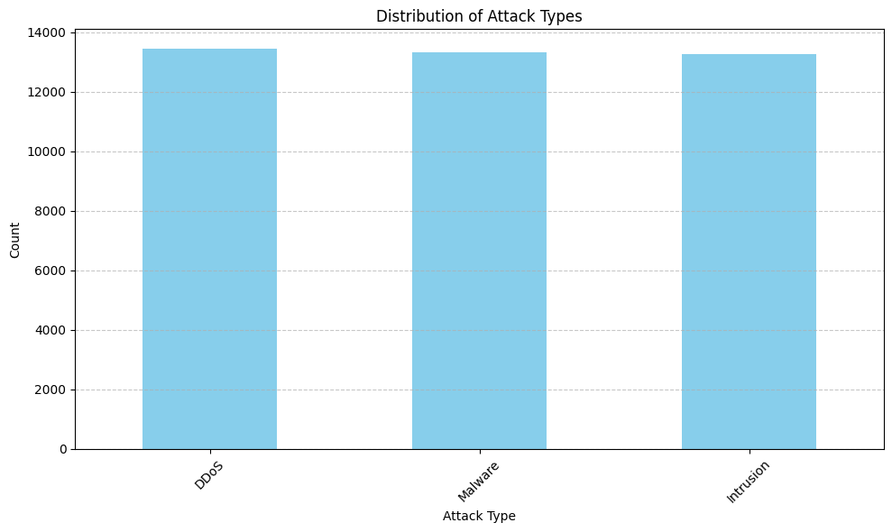

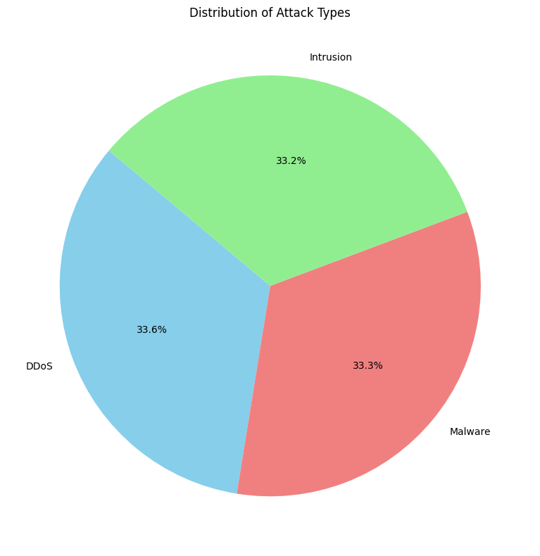

```python
import matplotlib.pyplot as plt

# Count the occurrences of each attack type
attack_counts = df['Attack Type'].value_counts()

# Plot the distribution of attack types
plt.figure(figsize=(10, 6))
attack_counts.plot(kind='bar', color='skyblue')
plt.title('Distribution of Attack Types')
plt.xlabel('Attack Type')
plt.ylabel('Count')
plt.xticks(rotation=45)
plt.grid(axis='y', linestyle='--', alpha=0.7)
plt.tight_layout()
plt.show()
# Create a pie chart for the distribution of attack types
plt.figure(figsize=(8, 8))
attack_counts.plot(kind='pie', autopct='%1.1f%%', startangle=140, colors=['skyblue', 'lightcoral', 'lightgreen'])
plt.title('Distribution of Attack Types')
plt.ylabel('')  # Remove the default y-axis label
plt.tight_layout()
plt.show()
```

Question: What Protocol was the most common?

Answer and Explanation: The analysis revealed that the most common protocol was ICMP with a value count of 13429. We were able to conclude this by using teh command 'df['Protocol'].value_counts()', which identifies and counts the occurences of each unique value within the specified column, in this case, 'Protocol'. To enhance this finding, we imported maplotlib to generate a visual representation that would provide a clean and concise depiction of the data distribution.

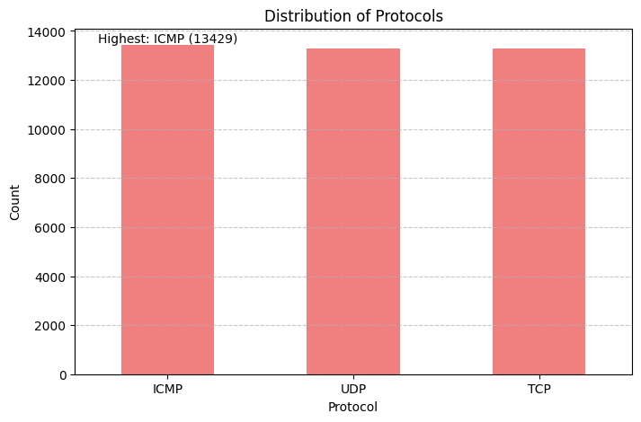

```python
import matplotlib.pyplot as plt

# Count the occurrences of each protocol
protocol_counts = df['Protocol'].value_counts()

# Plot the distribution of protocols
plt.figure(figsize=(8, 5))
protocol_counts.plot(kind='bar', color='lightcoral')
plt.title('Distribution of Protocols')
plt.xlabel('Protocol')
plt.ylabel('Count')
plt.xticks(rotation=0)
plt.grid(axis='y', linestyle='--', alpha=0.7)
plt.text(0, protocol_counts.max(), f"Highest: {protocol_counts.idxmax()} ({protocol_counts.max()})",
         ha='center', va='bottom', fontsize=10, color='black')
plt.show()
```

```python
import pandas as pd
df = pd.read_csv("/Users/andressanchez/Downloads/archive/cybersecurity_attacks.csv")
df.head()
df.info()
df.describe()
```

```
<class 'pandas.core.frame.DataFrame'>
RangeIndex: 40000 entries, 0 to 39999
Data columns (total 25 columns):
 #   Column                  Non-Null Count  Dtype
---  ------                  --------------  -----
 0   Timestamp               40000 non-null  object
 1   Source IP Address       40000 non-null  object
 2   Destination IP Address  40000 non-null  object
 3   Source Port             40000 non-null  int64
 4   Destination Port        40000 non-null  int64
 5   Protocol                40000 non-null  object
 6   Packet Length           40000 non-null  int64
 7   Packet Type             40000 non-null  object
 8   Traffic Type            40000 non-null  object
 9   Payload Data            40000 non-null  object
```

[output cut: 17 more lines]

|  | Source Port | Destination Port | Packet Length | Anomaly Scores |
| --- | --- | --- | --- | --- |
| count | 40000.000000 | 40000.000000 | 40000.000000 | 40000.000000 |
| mean | 32970.356450 | 33150.868650 | 781.452725 | 50.113473 |
| std | 18560.425604 | 18574.668842 | 416.044192 | 28.853598 |
| min | 1027.000000 | 1024.000000 | 64.000000 | 0.000000 |
| 25% | 16850.750000 | 17094.750000 | 420.000000 | 25.150000 |
| 50% | 32856.000000 | 33004.500000 | 782.000000 | 50.345000 |
| 75% | 48928.250000 | 49287.000000 | 1143.000000 | 75.030000 |
| max | 65530.000000 | 65535.000000 | 1500.000000 | 100.000000 |

Question: What was the highest anomaly score?

To answer this question, I analyzed the Anomaly Score column in the dataset. The highest anomaly score represents the most significant anomaly detected in the data.

```
The highest anomaly score is: 100.0
```

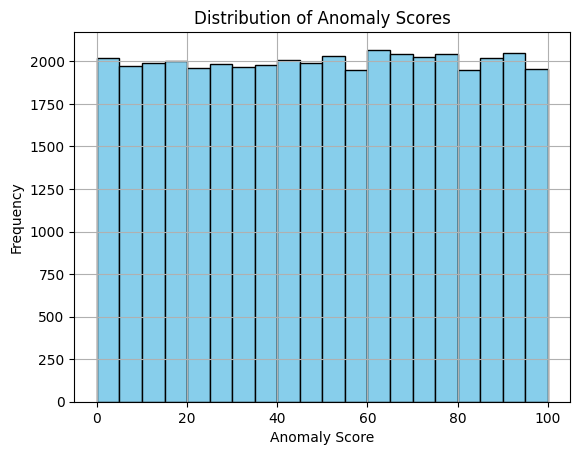

```python
highest_anomaly_score = df['Anomaly Scores'].max()

print("The highest anomaly score is:", highest_anomaly_score)

import matplotlib.pyplot as plt

# Plot the distribution of anomaly scores
df['Anomaly Scores'].hist(bins=20, color='skyblue', edgecolor='black')
plt.title('Distribution of Anomaly Scores')
plt.xlabel('Anomaly Score')
plt.ylabel('Frequency')
plt.show()
```

Question: Were most attacks Blocked, Logged, or Ignored?

To answer this question, I analyzed the Action Taken column in the dataset. This column categorizes the response to each attack as either Blocked, Logged, or Ignored. The analysis identifies the most common action taken and provides a breakdown of all actions.

```
The most common action taken is: Blocked

Breakdown of actions:
 Action Taken
Blocked    13529
Ignored    13276
Logged     13195
Name: count, dtype: int64
```

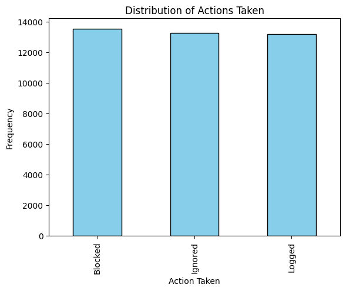

```python
action_counts = df['Action Taken'].value_counts()
most_common_action = action_counts.idxmax()

print("The most common action taken is:", most_common_action)
print("\nBreakdown of actions:\n", action_counts)

import matplotlib.pyplot as plt

# Plot the distribution of actions
action_counts.plot(kind='bar', color='skyblue', edgecolor='black')
plt.title('Distribution of Actions Taken')
plt.xlabel('Action Taken')
plt.ylabel('Frequency')
plt.show()
```

```python
import pandas as pd
```

```python
df = pd.read_csv("Data/cybersecurity_attacks.csv")
```

```python
df.describe()
```

|  | Source Port | Destination Port | Packet Length | Anomaly Scores |
| --- | --- | --- | --- | --- |
| count | 40000.000000 | 40000.000000 | 40000.000000 | 40000.000000 |
| mean | 32970.356450 | 33150.868650 | 781.452725 | 50.113473 |
| std | 18560.425604 | 18574.668842 | 416.044192 | 28.853598 |
| min | 1027.000000 | 1024.000000 | 64.000000 | 0.000000 |
| 25% | 16850.750000 | 17094.750000 | 420.000000 | 25.150000 |
| 50% | 32856.000000 | 33004.500000 | 782.000000 | 50.345000 |
| 75% | 48928.250000 | 49287.000000 | 1143.000000 | 75.030000 |
| max | 65530.000000 | 65535.000000 | 1500.000000 | 100.000000 |

This command is used to give a summary on the stats of the data file.

```python
df.columns  # shows the names of the columns in the data file
```

```
Index(['Timestamp', 'Source IP Address', 'Destination IP Address',
       'Source Port', 'Destination Port', 'Protocol', 'Packet Length',
       'Packet Type', 'Traffic Type', 'Payload Data', 'Malware Indicators',
       'Anomaly Scores', 'Alerts/Warnings', 'Attack Type', 'Attack Signature',
       'Action Taken', 'Severity Level', 'User Information',
       'Device Information', 'Network Segment', 'Geo-location Data',
       'Proxy Information', 'Firewall Logs', 'IDS/IPS Alerts', 'Log Source'],
      dtype='object')
```

This command shows the names of the columns in the data file. By usign this command, we are able to analyze and understand the data better.

```python
df.head()   # shows the first 5 rows of the data file
```

|  | Timestamp | Source IP Address | Destination IP Address | Source Port | Destination Port | Protocol | Packet Length | Packet Type | Traffic Type | Payload Data | ... | Action Taken | Severity Level | User Information | Device Information | Network Segment | Geo-location Data | Proxy Information | Firewall Logs | IDS/IPS Alerts | Log Source |
| --- | --- | --- | --- | --- | --- | --- | --- | --- | --- | --- | --- | --- | --- | --- | --- | --- | --- | --- | --- | --- | --- |
| 0 | 2023-05-30 06:33:58 | 103.216.15.12 | 84.9.164.252 | 31225 | 17616 | ICMP | 503 | Data | HTTP | Qui natus odio asperiores nam. Optio nobis ius... | ... | Logged | Low | Reyansh Dugal | Mozilla/5.0 (compatible; MSIE 8.0; Windows NT ... | Segment A | Jamshedpur, Sikkim | 150.9.97.135 | Log Data | NaN | Server |
| 1 | 2020-08-26 07:08:30 | 78.199.217.198 | 66.191.137.154 | 17245 | 48166 | ICMP | 1174 | Data | HTTP | Aperiam quos modi officiis veritatis rem. Omni... | ... | Blocked | Low | Sumer Rana | Mozilla/5.0 (compatible; MSIE 8.0; Windows NT ... | Segment B | Bilaspur, Nagaland | NaN | Log Data | NaN | Firewall |
| 2 | 2022-11-13 08:23:25 | 63.79.210.48 | 198.219.82.17 | 16811 | 53600 | UDP | 306 | Control | HTTP | Perferendis sapiente vitae soluta. Hic delectu... | ... | Ignored | Low | Himmat Karpe | Mozilla/5.0 (compatible; MSIE 9.0; Windows NT ... | Segment C | Bokaro, Rajasthan | 114.133.48.179 | Log Data | Alert Data | Firewall |
| 3 | 2023-07-02 10:38:46 | 163.42.196.10 | 101.228.192.255 | 20018 | 32534 | UDP | 385 | Data | HTTP | Totam maxime beatae expedita explicabo porro l... | ... | Blocked | Medium | Fateh Kibe | Mozilla/5.0 (Macintosh; PPC Mac OS X 10_11_5; ... | Segment B | Jaunpur, Rajasthan | NaN | NaN | Alert Data | Firewall |
| 4 | 2023-07-16 13:11:07 | 71.166.185.76 | 189.243.174.238 | 6131 | 26646 | TCP | 1462 | Data | DNS | Odit nesciunt dolorem nisi iste iusto. Animi v... | ... | Blocked | Low | Dhanush Chad | Mozilla/5.0 (compatible; MSIE 5.0; Windows NT ... | Segment C | Anantapur, Tripura | 149.6.110.119 | NaN | Alert Data | Firewall |

5 rows × 25 columns

This command shows the first five rows of the data file, and provides a quick overview of the structure and contenet of the dataset. It gives us a sample of the data, which is useful for exploring questions and understanding the dataset.

Question 1: What Attack was the most common?

Answer and explanation: The analysis revealed that Distributed Denial of Service (DDoS) attacks were the most prevalent type of attack within the dataset. This conclusion was derived using the command `df['Attack Type'].value_counts()`, which identifies and counts the occurrences of each unique value within the specified column, in this case, `'Attack Type'`. The results indicated that DDoS attacks had the highest frequency. To enhance the interpretability of this finding, the `matplotlib` library was utilized to generate a visual representation, providing a clear and concise depiction of the data distribution for the audience.

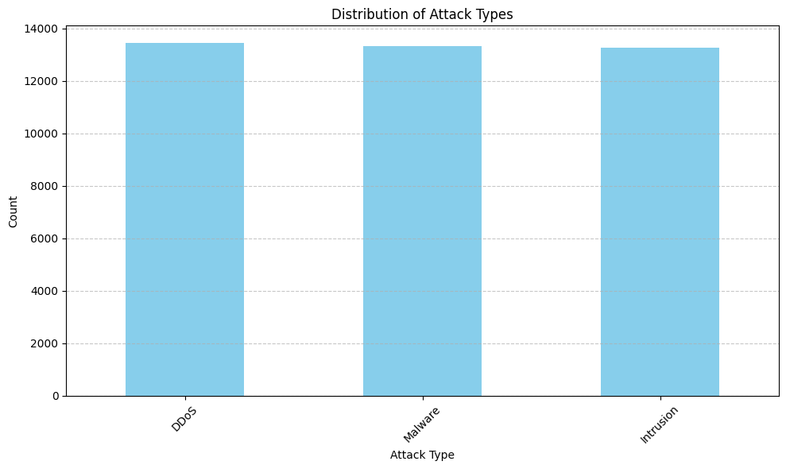

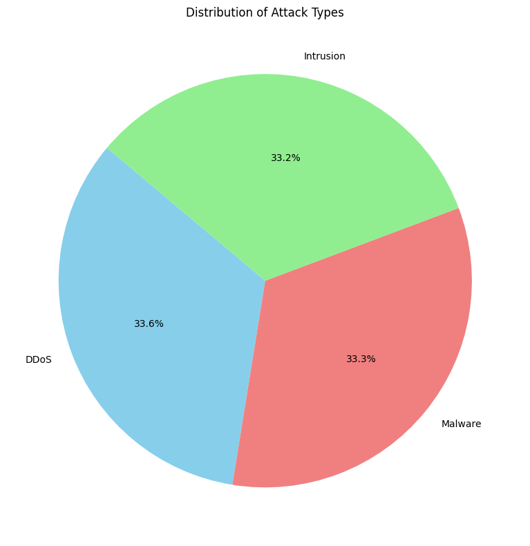

```python
import matplotlib.pyplot as plt

# Count the occurrences of each attack type
attack_counts = df['Attack Type'].value_counts()

# Plot the distribution of attack types
plt.figure(figsize=(10, 6))
attack_counts.plot(kind='bar', color='skyblue')
plt.title('Distribution of Attack Types')
plt.xlabel('Attack Type')
plt.ylabel('Count')
plt.xticks(rotation=45)
plt.grid(axis='y', linestyle='--', alpha=0.7)
plt.tight_layout()
plt.show()
# Create a pie chart for the distribution of attack types
plt.figure(figsize=(8, 8))
attack_counts.plot(kind='pie', autopct='%1.1f%%', startangle=140, colors=['skyblue', 'lightcoral', 'lightgreen'])
plt.title('Distribution of Attack Types')
plt.ylabel('')  # Remove the default y-axis label
plt.tight_layout()
plt.show()
```

Question: What Protocol was the most common?

Answer and Explanation: The analysis revealed that the most common protocol was ICMP with a value count of 13429. We were able to conclude this by using teh command 'df['Protocol'].value_counts()', which identifies and counts the occurences of each unique value within the specified column, in this case, 'Protocol'. To enhance this finding, we imported maplotlib to generate a visual representation that would provide a clean and concise depiction of the data distribution.

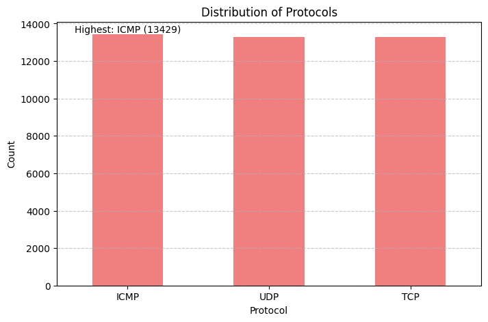

```python
import matplotlib.pyplot as plt

# Count the occurrences of each protocol
protocol_counts = df['Protocol'].value_counts()

# Plot the distribution of protocols
plt.figure(figsize=(8, 5))
protocol_counts.plot(kind='bar', color='lightcoral')
plt.title('Distribution of Protocols')
plt.xlabel('Protocol')
plt.ylabel('Count')
plt.xticks(rotation=0)
plt.grid(axis='y', linestyle='--', alpha=0.7)
plt.text(0, protocol_counts.max(), f"Highest: {protocol_counts.idxmax()} ({protocol_counts.max()})",
         ha='center', va='bottom', fontsize=10, color='black')
plt.show()
```

```python
import pandas as pd
df = pd.read_csv("/Users/andressanchez/Downloads/archive/cybersecurity_attacks.csv")
df.head()
df.info()
df.describe()
```

```
<class 'pandas.core.frame.DataFrame'>
RangeIndex: 40000 entries, 0 to 39999
Data columns (total 25 columns):
 #   Column                  Non-Null Count  Dtype
---  ------                  --------------  -----
 0   Timestamp               40000 non-null  object
 1   Source IP Address       40000 non-null  object
 2   Destination IP Address  40000 non-null  object
 3   Source Port             40000 non-null  int64
 4   Destination Port        40000 non-null  int64
 5   Protocol                40000 non-null  object
 6   Packet Length           40000 non-null  int64
 7   Packet Type             40000 non-null  object
 8   Traffic Type            40000 non-null  object
 9   Payload Data            40000 non-null  object
```

[output cut: 17 more lines]

[output not shown]

Question: What was the highest anomaly score?

To answer this question, I analyzed the Anomaly Score column in the dataset. The highest anomaly score represents the most significant anomaly detected in the data.

```
The highest anomaly score is: 100.0
```

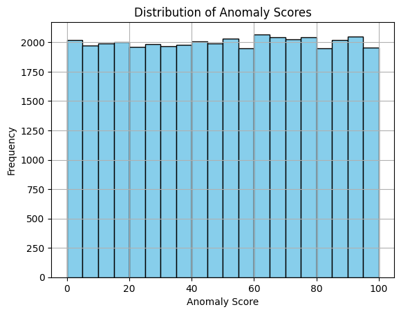

```python
highest_anomaly_score = df['Anomaly Scores'].max()

print("The highest anomaly score is:", highest_anomaly_score)

import matplotlib.pyplot as plt

# Plot the distribution of anomaly scores
df['Anomaly Scores'].hist(bins=20, color='skyblue', edgecolor='black')
plt.title('Distribution of Anomaly Scores')
plt.xlabel('Anomaly Score')
plt.ylabel('Frequency')
plt.show()
```

Question: Were most attacks Blocked, Logged, or Ignored?

To answer this question, I analyzed the Action Taken column in the dataset. This column categorizes the response to each attack as either Blocked, Logged, or Ignored. The analysis identifies the most common action taken and provides a breakdown of all actions.

```
The most common action taken is: Blocked

Breakdown of actions:
 Action Taken
Blocked    13529
Ignored    13276
Logged     13195
Name: count, dtype: int64
```

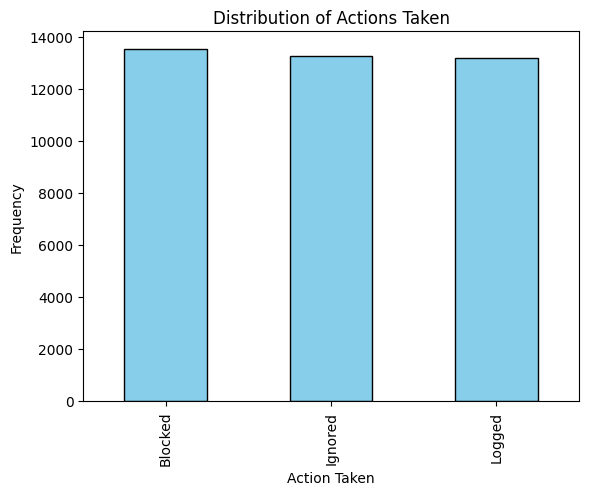

```python
action_counts = df['Action Taken'].value_counts()
most_common_action = action_counts.idxmax()

print("The most common action taken is:", most_common_action)
print("\nBreakdown of actions:\n", action_counts)

import matplotlib.pyplot as plt

# Plot the distribution of actions
action_counts.plot(kind='bar', color='skyblue', edgecolor='black')
plt.title('Distribution of Actions Taken')
plt.xlabel('Action Taken')
plt.ylabel('Frequency')
plt.show()
```